# Caption Contest — Methods & Results

```r
library(tidyverse)
library(psych)
library(knitr)
library(kableExtra)
library(effectsize)

source("scripts/_helpers/tex_numbers.R")
NUMS <- "output/numbers/results.tex"

# Start fresh
writeLines("% Auto-generated by results.qmd. Do not edit by hand.\n", NUMS)

df <- read_csv("data_clean.csv", show_col_types = FALSE) |>
  mutate(
    condition = factor(condition, levels = c("solo", "ai")),
    study     = factor(study, levels = c("prolific3", "connect1")),
    feedback_type = factor(feedback_type, levels = c("none", "honest_coarsened"))
  )
```

# Methods

## Participants

We randomly assigned 182 participants to write a caption for a *New Yorker*-style cartoon either alone (solo; *n* = 94) or with access to an AI writing tool (AI; *n* = 88). We recruited 15 participants from Prolific and 167 from CloudResearch Connect.

```r
# Write sample size numbers to LaTeX
write_tex_command(NUMS, "NTotal",    nrow(df), digits = 0)
write_tex_command(NUMS, "NSolo",     sum(df$condition == "solo"), digits = 0)
write_tex_command(NUMS, "NAI",       sum(df$condition == "ai"), digits = 0)
write_tex_command(NUMS, "NProlific", sum(df$study == "prolific3"), digits = 0)
write_tex_command(NUMS, "NConnect",  sum(df$study == "connect1"), digits = 0)
write_tex_command(NUMS, "NFlagged",  sum(df$moderation_flagged), digits = 0)
write_tex_command(NUMS, "NMissingSurvey", sum(is.na(df$process_agency)), digits = 0)
write_tex_command(NUMS, "PctMissingSurvey",
  sprintf("%.0f\\%%", 100 * mean(is.na(df$process_agency))), force_latex = TRUE)
write_tex_command(NUMS, "AIUsesMean", mean(df$n_ai_uses[df$condition == "ai"]), digits = 1)
write_tex_command(NUMS, "AIUsesSD",   sd(df$n_ai_uses[df$condition == "ai"]), digits = 1)
```

```r
# HTML display table
df |>
  count(condition, study) |>
  pivot_wider(names_from = study, values_from = n, values_fill = 0) |>
  mutate(total = prolific3 + connect1) |>
  bind_rows(
    tibble(condition = "Total",
           prolific3 = sum(df$study == "prolific3"),
           connect1  = sum(df$study == "connect1"),
           total     = nrow(df))
  ) |>
  kable(col.names = c("Condition", "Prolific", "Connect", "Total")) |>
  kable_styling(bootstrap_options = c("striped", "hover"), full_width = FALSE)
```

| Condition | Prolific | Connect | Total |
| --- | --- | --- | --- |
| solo | 9 | 85 | 94 |
| ai | 6 | 82 | 88 |
| Total | 15 | 167 | 182 |

```r
# LaTeX sample table
sample_tbl <- df |>
  count(condition, study) |>
  pivot_wider(names_from = study, values_from = n, values_fill = 0) |>
  mutate(total = prolific3 + connect1) |>
  bind_rows(
    tibble(condition = "Total",
           prolific3 = sum(df$study == "prolific3"),
           connect1  = sum(df$study == "connect1"),
           total     = nrow(df))
  ) |>
  mutate(condition = if_else(condition == "Total", "\\midrule Total", condition))

tex_lines <- c(
  "% Auto-generated. Do not edit by hand.",
  "\\begin{tabular}{lrrr}",
  "\\toprule",
  "Condition & Prolific & Connect & Total \\\\",
  "\\midrule",
  paste0(sample_tbl$condition, " & ", sample_tbl$prolific3, " & ",
         sample_tbl$connect1, " & ", sample_tbl$total, " \\\\"),
  "\\bottomrule",
  "\\end{tabular}"
)
# Fix the midrule hack
tex_lines <- gsub("\\\\midrule Total", "\\\\midrule\nTotal", tex_lines)
writeLines(tex_lines, "output/tables/tab_sample.tex")
```

All participants passed the honeypot bot check. Automated moderation flagged 4 captions, which we retained (excluding them does not change results). 29 participants (16%) completed the caption task but not the post-task survey; this missingness did not differ by condition ($\chi^2$ test below).

```r
miss_tbl <- df |>
  mutate(survey_missing = is.na(process_agency)) |>
  count(condition, survey_missing) |>
  pivot_wider(names_from = survey_missing, values_from = n, values_fill = 0)

chisq_miss <- chisq.test(matrix(c(miss_tbl$`FALSE`, miss_tbl$`TRUE`), nrow = 2))
cat(sprintf("Survey missingness by condition: χ²(1) = %.2f, p = %.3f\n",
            chisq_miss$statistic, chisq_miss$p.value))
```

```
Survey missingness by condition: χ²(1) = 1.04, p = 0.307
```

```r
write_tex_command(NUMS, "MissChiSq", chisq_miss$statistic, digits = 2)
write_tex_command(NUMS, "MissChiP",  fmt_p(chisq_miss$p.value), force_latex = TRUE)
```

## Procedure

Each participant viewed a cartoon and wrote the funniest caption they could. Solo participants wrote unaided. AI participants could request AI-generated caption ideas, which they did an average of 2.1 times (*SD* = 2.5).

After submitting their caption, participants rated their experience on four sets of 0–10 scales: process agency (3 items: “I felt like I was producing the work,” “I felt responsible for the output,” “I felt involved in the process”), outcome agency (3 items: “How capably/effectively/powerfully did you produce a funny caption?”), meaning (3 items: fulfilling, meaningful, mattered), and humor identity (3 items: funny, importance, reflects).

## Measures

Three independent methods assessed **caption quality**: (1) Elo ratings from pairwise votes by other participants, (2) a pretrained humor model (0–100), and (3) LLM judge ratings on humor, cleverness, fit, and overall quality (each 1–10).

**Task behavior** measures included total keystrokes, task duration (seconds), and number of AI uses.

We computed **survey composites** as the mean of each scale’s items. All four composites showed acceptable internal consistency (see codebook in `clean_data.qmd`).

# Results

## Descriptive Statistics

```r
dvs <- c("elo", "pretrained_score", "llm_humor", "llm_cleverness", "llm_fit", "llm_overall",
         "n_keystrokes", "task_duration_s",
         "process_agency", "outcome_agency", "meaning", "identity")

dv_labels <- c("Elo rating", "Pretrained score", "LLM: Humor", "LLM: Cleverness",
               "LLM: Fit", "LLM: Overall",
               "Keystrokes", "Task duration (s)",
               "Process agency", "Outcome agency", "Meaning", "Identity")

desc <- map2_dfr(dvs, dv_labels, function(v, lab) {
  df |>
    filter(!is.na(.data[[v]])) |>
    group_by(condition) |>
    summarise(n = n(), m = mean(.data[[v]]), sd = sd(.data[[v]]), .groups = "drop") |>
    mutate(variable = lab) |>
    select(variable, condition, n, m, sd)
}) |>
  pivot_wider(
    names_from = condition,
    values_from = c(n, m, sd),
    names_glue = "{condition}_{.value}"
  ) |>
  select(variable, solo_n, solo_m, solo_sd, ai_n, ai_m, ai_sd)

desc |>
  mutate(across(c(solo_m, solo_sd, ai_m, ai_sd), \(x) sprintf("%.2f", x))) |>
  kable(col.names = c("Variable", "n", "M", "SD", "n", "M", "SD")) |>
  kable_styling(bootstrap_options = c("striped", "hover", "condensed"), full_width = FALSE) |>
  add_header_above(c(" " = 1, "Solo" = 3, "AI" = 3)) |>
  pack_rows("Caption Quality", 1, 6) |>
  pack_rows("Task Behavior", 7, 8) |>
  pack_rows("Survey Composites", 9, 12)
```

| Variable | Solo n | Solo M | Solo SD | AI n | AI M | AI SD |
| --- | --- | --- | --- | --- | --- | --- |
| **Caption Quality** |  |  |  |  |  |  |
| Elo rating | 94 | 1488.22 | 91.55 | 88 | 1517.90 | 78.78 |
| Pretrained score | 76 | 47.39 | 22.57 | 78 | 52.82 | 20.84 |
| LLM: Humor | 76 | 6.32 | 0.73 | 78 | 6.44 | 0.73 |
| LLM: Cleverness | 76 | 6.96 | 0.97 | 78 | 7.28 | 0.80 |
| LLM: Fit | 76 | 8.38 | 0.67 | 78 | 8.49 | 0.68 |
| LLM: Overall | 76 | 7.14 | 0.78 | 78 | 7.38 | 0.72 |
| **Task Behavior** |  |  |  |  |  |  |
| Keystrokes | 94 | 87.40 | 103.61 | 88 | 66.92 | 88.77 |
| Task duration (s) | 94 | 117.10 | 100.27 | 88 | 107.99 | 122.28 |
| **Survey Composites** |  |  |  |  |  |  |
| Process agency | 76 | 8.86 | 1.78 | 77 | 6.40 | 3.91 |
| Outcome agency | 75 | 5.46 | 2.43 | 76 | 5.68 | 2.94 |
| Meaning | 75 | 5.32 | 2.70 | 76 | 4.58 | 3.21 |
| Identity | 76 | 6.36 | 2.04 | 77 | 6.13 | 2.44 |

## Condition Differences

We tested for condition differences using Welch’s two-sample *t*-tests. Effect sizes are reported as Cohen’s *d* (positive *d* = solo > AI).

```r
# Macro prefixes for each DV (used in LaTeX as \EloMeanSolo, \EloT, etc.)
tex_prefixes <- c("Elo", "Pretrained", "LLMHumor", "LLMClever", "LLMFit", "LLMOverall",
                  "Keystrokes", "Duration",
                  "ProcAgency", "OutAgency", "Meaning", "Identity")

results <- map2_dfr(seq_along(dvs), dvs, function(i, v) {
  d <- df |> filter(!is.na(.data[[v]]))
  solo_vals <- d |> filter(condition == "solo") |> pull(!!sym(v))
  ai_vals   <- d |> filter(condition == "ai")   |> pull(!!sym(v))

  # Write LaTeX numbers
  write_ttest_block(NUMS, tex_prefixes[i], solo_vals, ai_vals)

  tt <- t.test(solo_vals, ai_vals)
  pooled_sd <- sqrt((sd(solo_vals)^2 + sd(ai_vals)^2) / 2)
  d_val <- (mean(solo_vals) - mean(ai_vals)) / pooled_sd

  tibble(
    variable = dv_labels[i],
    solo_m = mean(solo_vals), ai_m = mean(ai_vals),
    diff = mean(solo_vals) - mean(ai_vals),
    d = d_val,
    t = tt$statistic,
    df = tt$parameter,
    p = tt$p.value
  )
})

# ── HTML display table ──
results |>
  mutate(
    across(c(solo_m, ai_m, diff, d, t), \(x) sprintf("%.2f", x)),
    df = sprintf("%.0f", as.numeric(df)),
    sig = case_when(
      p < .001 ~ "***",
      p < .01  ~ "**",
      p < .05  ~ "*",
      p < .10  ~ "†",
      TRUE     ~ ""
    ),
    p = ifelse(p < .001, "<.001", sprintf("%.3f", p))
  ) |>
  select(variable, diff, d, t, df, p, sig) |>
  kable(col.names = c("Variable", "Δ (Solo − AI)", "Cohen's d", "t", "df", "p", ""),
        align = c("l", rep("r", 6))) |>
  kable_styling(bootstrap_options = c("striped", "hover", "condensed"), full_width = FALSE) |>
  pack_rows("Caption Quality", 1, 6) |>
  pack_rows("Task Behavior", 7, 8) |>
  pack_rows("Survey Composites", 9, 12) |>
  footnote(general = "† p < .10, * p < .05, ** p < .01, *** p < .001. Positive d = solo higher.")
```

| Variable | Δ (Solo − AI) | Cohen's d | t | df | p |  |
| --- | --- | --- | --- | --- | --- | --- |
| **Caption Quality** |  |  |  |  |  |  |
| Elo rating | -29.67 | -0.35 | -2.35 | 179 | 0.020 | * |
| Pretrained score | -5.43 | -0.25 | -1.55 | 150 | 0.123 |  |
| LLM: Humor | -0.12 | -0.16 | -1.02 | 152 | 0.311 |  |
| LLM: Cleverness | -0.32 | -0.36 | -2.23 | 145 | 0.027 | * |
| LLM: Fit | -0.11 | -0.16 | -0.97 | 152 | 0.334 |  |
| LLM: Overall | -0.24 | -0.32 | -1.98 | 151 | 0.050 | * |
| **Task Behavior** |  |  |  |  |  |  |
| Keystrokes | 20.48 | 0.21 | 1.44 | 179 | 0.153 |  |
| Task duration (s) | 9.11 | 0.08 | 0.55 | 169 | 0.585 |  |
| **Survey Composites** |  |  |  |  |  |  |
| Process agency | 2.47 | 0.81 | 5.03 | 107 | <.001 | *** |
| Outcome agency | -0.23 | -0.08 | -0.52 | 145 | 0.606 |  |
| Meaning | 0.73 | 0.25 | 1.52 | 145 | 0.131 |  |
| Identity | 0.23 | 0.10 | 0.62 | 147 | 0.536 |  |

Note:  
† p < .10, * p < .05, ** p < .01, *** p < .001. Positive d = solo higher.

```r
# ── LaTeX condition-differences table ──
fmt_p_tab <- function(p) ifelse(p < .001, "$<$.001", sub("^0", "", sprintf("%.3f", p)))
fmt_sig <- function(p) case_when(p < .001 ~ "***", p < .01 ~ "**", p < .05 ~ "*", p < .10 ~ "\\dag", TRUE ~ "")

tex_rows <- results |>
  mutate(
    row = sprintf("%s & %.2f & %.2f & %.2f & %.2f & %.2f & %s%s \\\\",
                  variable, solo_m, ai_m, diff, abs(d), abs(t),
                  fmt_p_tab(p), fmt_sig(p))
  )

# Insert midrule group headers
quality_rows  <- tex_rows$row[1:6]
behavior_rows <- tex_rows$row[7:8]
survey_rows   <- tex_rows$row[9:12]

tex_tbl <- c(
  "% Auto-generated. Do not edit by hand.",
  "\\begin{tabular}{lrrrrrr}",
  "\\toprule",
  " & \\multicolumn{1}{c}{$M_{\\text{Solo}}$} & \\multicolumn{1}{c}{$M_{\\text{AI}}$} & \\multicolumn{1}{c}{$\\Delta$} & \\multicolumn{1}{c}{$d$} & \\multicolumn{1}{c}{$t$} & \\multicolumn{1}{c}{$p$} \\\\",
  "\\midrule",
  "\\multicolumn{7}{l}{\\textit{Caption Quality}} \\\\",
  quality_rows,
  "\\addlinespace",
  "\\multicolumn{7}{l}{\\textit{Task Behavior}} \\\\",
  behavior_rows,
  "\\addlinespace",
  "\\multicolumn{7}{l}{\\textit{Survey Composites}} \\\\",
  survey_rows,
  "\\bottomrule",
  "\\multicolumn{7}{l}{\\footnotesize $\\dag$ $p < .10$, * $p < .05$, ** $p < .01$, *** $p < .001$. Positive $d$ = solo higher.} \\\\",
  "\\end{tabular}"
)
writeLines(tex_tbl, "output/tables/tab_condition_tests.tex")
```

## AI Improved Output but Undermined Ownership

```r
get_stats <- function(var_label) {
  results |> filter(variable == var_label)
}

s_elo   <- get_stats("Elo rating")
s_clev  <- get_stats("LLM: Cleverness")
s_proc  <- get_stats("Process agency")
s_out   <- get_stats("Outcome agency")
s_mean  <- get_stats("Meaning")
s_ident <- get_stats("Identity")
s_key   <- get_stats("Keystrokes")
s_dur   <- get_stats("Task duration (s)")
```

### AI did not reduce effort

AI participants typed just as much and spent just as long on the task as solo participants (keystrokes: *t*(179) = 1.44, *p* = 0.153; duration: *t*(169) = 0.55, *p* = 0.585). AI participants used the tool an average of 2.1 times, but this supplemented rather than replaced their own writing effort.

### AI sharply reduced process agency

AI participants felt far less ownership over the creative process (*M*<sub>AI</sub> = 6.40 vs. *M*<sub>solo</sub> = 8.86; *t*(107) = 5.03, *p* < .001, *d* = 0.81). On a 0–10 scale, solo participants averaged nearly 9; AI participants averaged just above 6. They felt less like they were producing the work, less responsible for the output, and less involved in the process.

### Yet outcome agency did not budge

Outcome agency held flat across conditions (*M*<sub>AI</sub> = 5.68 vs. *M*<sub>solo</sub> = 5.46; *t*(145) = -0.52, *p* = 0.606, *d* = 0.08). AI participants produced objectively better captions, but did not feel more capable, effective, or powerful. They did not internalize the AI’s contribution as their own.

### Meaning and identity were unaffected

Neither meaning (*d* = 0.25, *p* = 0.131) nor humor identity (*d* = 0.10, *p* = 0.536) differed by condition, though meaning trended lower among AI participants.

## Summary Figure

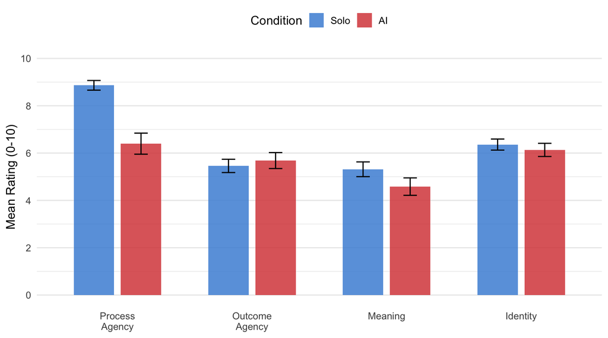

```r
plot_data <- df |>
  select(condition, process_agency, outcome_agency, meaning, identity) |>
  pivot_longer(-condition, names_to = "composite", values_to = "value") |>
  filter(!is.na(value)) |>
  mutate(composite = factor(composite,
    levels = c("process_agency", "outcome_agency", "meaning", "identity"),
    labels = c("Process\nAgency", "Outcome\nAgency", "Meaning", "Identity")
  ))

plot_summary <- plot_data |>
  group_by(condition, composite) |>
  summarise(
    m  = mean(value),
    se = sd(value) / sqrt(n()),
    .groups = "drop"
  )

p_composites <- ggplot(plot_summary, aes(x = composite, y = m, fill = condition)) +
  geom_col(position = position_dodge(0.7), width = 0.6, alpha = 0.85) +
  geom_errorbar(aes(ymin = m - se, ymax = m + se),
                position = position_dodge(0.7), width = 0.2) +
  scale_fill_manual(values = c("solo" = "#4A90D9", "ai" = "#D94A4A"),
                    labels = c("Solo", "AI")) +
  scale_y_continuous(limits = c(0, 10), breaks = seq(0, 10, 2)) +
  labs(x = NULL, y = "Mean Rating (0-10)", fill = "Condition") +
  theme_minimal(base_size = 13) +
  theme(
    legend.position = "top",
    panel.grid.major.x = element_blank()
  )

p_composites
```

```r
ggsave("output/figures/fig_composites.pdf", p_composites, width = 7, height = 4.5)
```

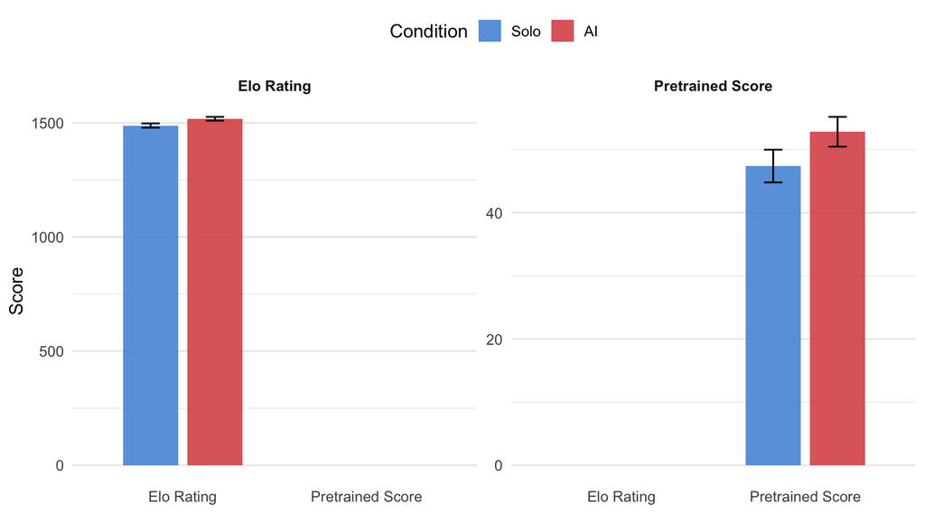

```r
quality_data <- df |>
  select(condition, elo, pretrained_score) |>
  pivot_longer(-condition, names_to = "measure", values_to = "value") |>
  filter(!is.na(value)) |>
  mutate(measure = factor(measure,
    levels = c("elo", "pretrained_score"),
    labels = c("Elo Rating", "Pretrained Score")
  ))

quality_summary <- quality_data |>
  group_by(condition, measure) |>
  summarise(m = mean(value), se = sd(value) / sqrt(n()), .groups = "drop")

p_quality <- ggplot(quality_summary, aes(x = measure, y = m, fill = condition)) +
  geom_col(position = position_dodge(0.7), width = 0.6, alpha = 0.85) +
  geom_errorbar(aes(ymin = m - se, ymax = m + se),
                position = position_dodge(0.7), width = 0.2) +
  scale_fill_manual(values = c("solo" = "#4A90D9", "ai" = "#D94A4A"),
                    labels = c("Solo", "AI")) +
  facet_wrap(~measure, scales = "free_y") +
  labs(x = NULL, y = "Score", fill = "Condition") +
  theme_minimal(base_size = 13) +
  theme(
    legend.position = "top",
    panel.grid.major.x = element_blank(),
    strip.text = element_text(face = "bold")
  )

p_quality
```

```r
ggsave("output/figures/fig_quality.pdf", p_quality, width = 7, height = 4.5)
```